# Portfolio basic analysis

```python
import yfinance as yf
import pandas as pd

def fetch_data(tickers, start_date, end_date):
    """
    Fetch historical price data for given tickers.
    :param tickers: List of stock tickers.
    :param start_date: Start date for the historical data.
    :param end_date: End date for the historical data.
    :return: DataFrame with adjusted closing prices.
    """

    data = yf.download(tickers, start=start_date, end=end_date)['Adj Close']
    return data

tickers = ["BWXT", "CEG", "NEE", "VRT"]  # Add 'SWEC-B.ST' if supported
data = yf.download(tickers, start="2022-02-01", end="2024-12-05")['Adj Close']

print(data.head())
```

```
[*********************100%***********************]  4 of 4 completed
```

```
Ticker           BWXT        CEG        NEE        VRT
Date
2022-02-01  42.573887  48.401463  71.459686  21.056982
2022-02-02  42.689320  51.542011  71.922325  21.276430
2022-02-03  42.362278  52.135120  70.108765  20.877434
2022-02-04  41.688938  48.751492  70.330826  21.276430
2022-02-07  42.054462  44.794205  70.025482  21.565702
```

### Calculate daily returns from price data.

Process:

```python
def calculate_daily_returns(price_data):
    """
    Calculate daily returns from price data.
    :param price_data: DataFrame of historical prices.
    :return: DataFrame of daily returns.
    """
    return price_data.pct_change().dropna()

returns = calculate_daily_returns(data)
print(returns.head())
```

```
Ticker          BWXT       CEG       NEE       VRT
Date
2022-02-02  0.002711  0.064885  0.006474  0.010422
2022-02-03 -0.007661  0.011507 -0.025216 -0.018753
2022-02-04 -0.015895 -0.064901  0.003167  0.019111
2022-02-07  0.008768 -0.081173 -0.004342  0.013596
2022-02-08  0.010979 -0.012372 -0.002907  0.041628
```

### Correlation/Covariance matrices - Essential for understanding relationships between assets

Covariance

Purpose: The covariance matrix quantifies how the returns of different assets move relative to each other. It is a fundamental component for understanding portfolio risk.

Process:

- Computes the covariance of daily returns for all pairs of assets in the portfolio.
- This matrix serves as an input for portfolio optimization and risk assessment.

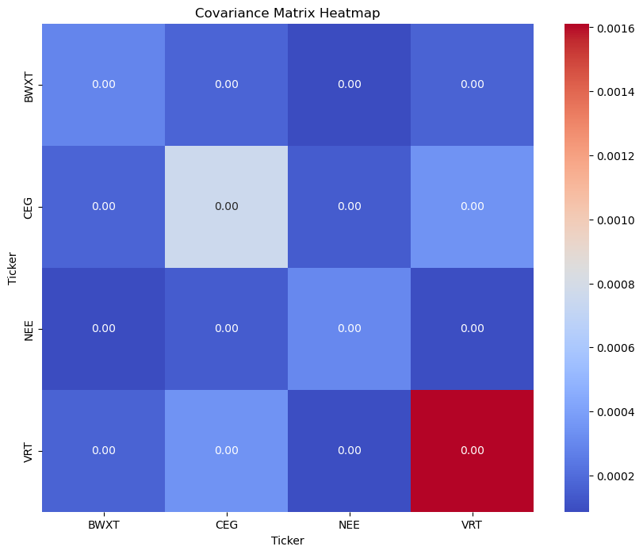

```python
import matplotlib.pyplot as plt
import seaborn as sns

def plot_covariance_matrix(returns):
    """
    Plot covariance matrix heatmap.
    :param returns: DataFrame of daily returns.
    """
    covariance_matrix = returns.cov()
    plt.figure(figsize=(10, 8))
    sns.heatmap(covariance_matrix, annot=True, fmt=".2f", cmap="coolwarm")
    plt.title("Covariance Matrix Heatmap")
    plt.show()

plot_covariance_matrix(returns)
```

Correlation

Purpose: The correlation matrix standardizes the covariance values, providing insight into the strength and direction of relationships between asset returns.

Process:

- Calculates pairwise correlations of daily returns.
- A heatmap is typically plotted to visually represent these relationships, aiding in diversification analysis.

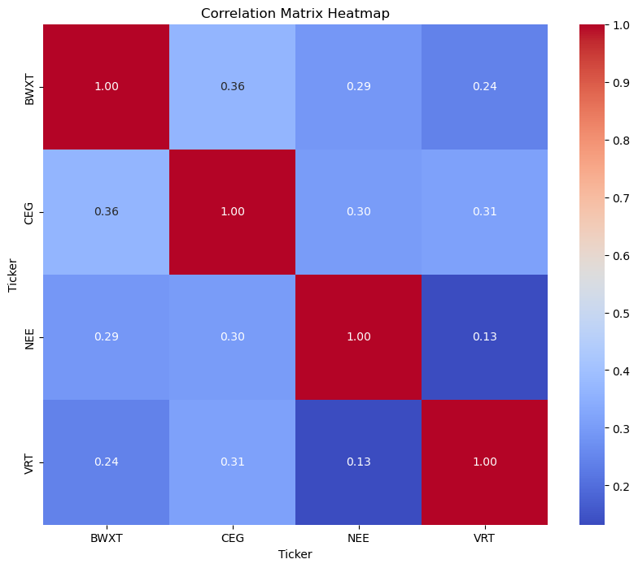

```python
def plot_correlation_matrix(returns):
    """
    Plot correlation matrix heatmap.
    :param returns: DataFrame of daily returns.
    """
    correlation_matrix = returns.corr()
    plt.figure(figsize=(10, 8))
    sns.heatmap(correlation_matrix, annot=True, fmt=".2f", cmap="coolwarm")
    plt.title("Correlation Matrix Heatmap")
    plt.show()

plot_correlation_matrix(returns)
```

### Mean-Variance Optimization (CAPM-inspired)

This section calculates the optimal portfolio weights using mean-variance optimization.

```python
import numpy as np
import pandas as pd

# Simulated returns and covariance matrix
expected_returns = np.array([0.05, 0.07, 0.12])  # Example expected returns for assets
cov_matrix = np.array([
    [0.01, 0.0018, 0.0011],
    [0.0018, 0.0109, 0.0026],
    [0.0011, 0.0026, 0.0199]
])  # Example covariance matrix
risk_free_rate = 0.03  # Risk-free rate

# Calculate excess returns
excess_returns = expected_returns - risk_free_rate

# Mean-variance optimization
ones = np.ones(len(expected_returns))
inv_cov_matrix = np.linalg.inv(cov_matrix)
weights = np.dot(inv_cov_matrix, excess_returns) / np.dot(ones.T, np.dot(inv_cov_matrix, excess_returns))

# Print results
print("Optimal Portfolio Weights (Mean-Variance Optimization):", weights)
```

```
Optimal Portfolio Weights (Mean-Variance Optimization): [0.14156923 0.3236504  0.53478037]
```

### Black-Litterman Model

The Black-Litterman model starts with market equilibrium (CAPM-implied returns) and adjusts them based on subjective investor views.

The model combines prior market data (mean returns and covariance) with investor views (expressed as relative or absolute performance expectations) to compute adjusted expected returns. This allows for a more flexible portfolio allocation.

```python
from numpy.linalg import inv

# Market data
market_weights = np.array([0.4, 0.3, 0.3])  # Market portfolio weights
market_cov = cov_matrix  # Market covariance matrix
market_risk_aversion = 3.0  # Risk aversion coefficient

# Market equilibrium returns
pi = market_risk_aversion * np.dot(market_cov, market_weights)

# Investor's views
P = np.array([[1, 0, -1], [0, 1, -1]])  # Investor's views on relative asset performance
Q = np.array([0.02, 0.01])  # Expected returns of views
omega = np.diag([0.0001, 0.0001])  # Confidence in views

# Black-Litterman posterior returns
M_inverse = inv(inv(market_cov) + np.dot(P.T, inv(omega).dot(P)))
bl_returns = M_inverse.dot(np.dot(inv(market_cov), pi) + np.dot(P.T, inv(omega).dot(Q)))

# Print results
print("Black-Litterman Adjusted Returns:", bl_returns)
```

```
Black-Litterman Adjusted Returns: [0.02331177 0.01341105 0.00340965]
```

### CVaR optimization - This is a robust risk measure that's better than traditional variance

Purpose: CVaR estimates the expected loss in the worst-case scenario beyond a certain confidence level, offering a more comprehensive risk measure than VaR. Process:

- Computes losses exceeding the Value at Risk (VaR) threshold.
- Useful for risk-averse investors to understand tail risks in the portfolio.

```python
import numpy as np
import cvxpy as cp

def optimize_portfolio_cvar(returns, confidence_level=0.95):
    """
    Optimize portfolio using CVaR minimization.
    :param returns: DataFrame of daily returns.
    :param confidence_level: Confidence level for CVaR.
    :return: Optimal weights for the portfolio.
    """
    n_assets = returns.shape[1]
    weights = cp.Variable(n_assets)  # Portfolio weights
    z = cp.Variable(len(returns))  # Slack variables for CVaR
    VaR = cp.Variable()  # Value at Risk

    # Portfolio return
    portfolio_returns = returns.values @ weights

    # CVaR constraints
    cvar_constraints = [
        z >= -portfolio_returns - VaR,
        z >= 0,
        cp.sum(weights) == 1,  # Weights sum to 1
        weights >= 0  # No shorting
    ]

    # Objective: Minimize CVaR
    cvar = VaR + (1 / ((1 - confidence_level) * len(returns))) * cp.sum(z)
    problem = cp.Problem(cp.Minimize(cvar), cvar_constraints)
    problem.solve()

    return weights.value

optimal_weights = optimize_portfolio_cvar(returns)
print("Optimal Weights:", optimal_weights)
```

```
Optimal Weights: [0.52637724 0.09456331 0.36787789 0.01118156]
```

### Basic portfolio allocation evaluation

Purpose: Determines portfolio returns and risk based on user-defined weights for assets.

Process:

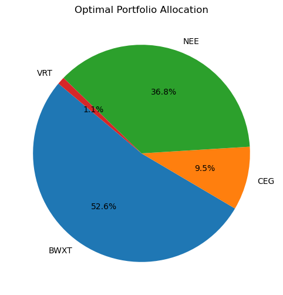

```python
import matplotlib.pyplot as plt

def plot_portfolio_allocation(weights, tickers):
    """
    Plot portfolio allocation.
    :param weights: Optimized weights.
    :param tickers: List of tickers.
    """
    plt.figure(figsize=(8, 6))
    plt.pie(weights, labels=tickers, autopct='%1.1f%%', startangle=140)
    plt.title("Optimal Portfolio Allocation")
    plt.show()

plot_portfolio_allocation(optimal_weights, tickers)
```

Evaluate portfolio performance Purpose: Evaluates the performance of a portfolio given user-defined weights for the assets.

Process:

Multiplies the daily returns of each asset by its respective weight in the portfolio.

Aggregates these weighted returns to calculate the total portfolio return.

```python
def evaluate_portfolio(returns, weights):
    """
    Evaluate portfolio performance.
    :param returns: DataFrame of daily returns.
    :param weights: Optimized weights.
    :return: Portfolio mean return and standard deviation.
    """
    portfolio_return = np.dot(returns.mean(), weights) * 252  # Annualized return
    portfolio_volatility = np.sqrt(np.dot(weights.T, np.dot(returns.cov() * 252, weights)))  # Annualized volatility
    return portfolio_return, portfolio_volatility

portfolio_return, portfolio_volatility = evaluate_portfolio(returns, optimal_weights)
print(f"Portfolio Annualized Return: {portfolio_return:.2f}")
print(f"Portfolio Annualized Volatility: {portfolio_volatility:.2f}")
```

```
Portfolio Annualized Return: 0.32
Portfolio Annualized Volatility: 0.22
```

### Efficient frontier analysis - Valuable for portfolio optimization visualization

The curve's shape shows the tradeoff between risk and return

The upper edge of the curve is the "efficient frontier" - these are the optimal portfolios

Portfolios below the frontier are suboptimal because you could get higher returns for the same risk.

- Portfolio Selection:

Conservative investors might prefer portfolios on the left (lower risk, lower return)

Aggressive investors might prefer portfolios on the right (higher risk, higher return)

The red dot (max Sharpe ratio) represents the theoretically optimal portfolio for risk-adjusted returns

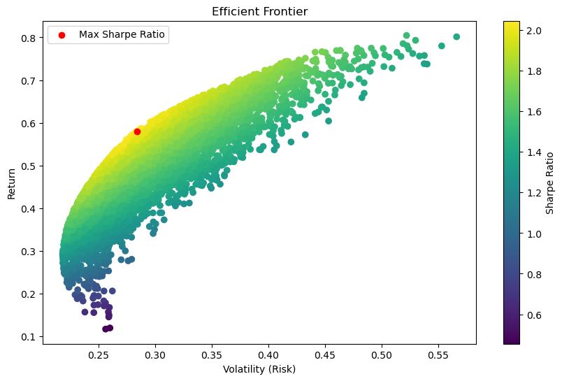

```python
def plot_efficient_frontier(returns, num_portfolios=10000):
    """
    Plot efficient frontier.
    :param returns: DataFrame of daily returns.
    :param num_portfolios: Number of portfolios to simulate.
    """
    n_assets = returns.shape[1]
    mean_returns = returns.mean() * 252
    cov_matrix = returns.cov() * 252
    results = np.zeros((3, num_portfolios))
    weights_record = []

    for i in range(num_portfolios):
        weights = np.random.random(n_assets)
        weights /= np.sum(weights)
        portfolio_return = np.dot(weights, mean_returns)
        portfolio_volatility = np.sqrt(np.dot(weights.T, np.dot(cov_matrix, weights)))
        results[0, i] = portfolio_volatility
        results[1, i] = portfolio_return
        results[2, i] = results[1, i] / results[0, i]  # Sharpe Ratio
        weights_record.append(weights)

    max_sharpe_idx = np.argmax(results[2])
    max_sharpe_weights = weights_record[max_sharpe_idx]

    plt.figure(figsize=(10, 6))
    plt.scatter(results[0, :], results[1, :], c=results[2, :], cmap='viridis')
    plt.colorbar(label="Sharpe Ratio")
    plt.scatter(results[0, max_sharpe_idx], results[1, max_sharpe_idx], color="red", label="Max Sharpe Ratio")
    plt.title("Efficient Frontier")
    plt.xlabel("Volatility (Risk)")
    plt.ylabel("Return")
    plt.legend()
    plt.show()

plot_efficient_frontier(returns)
```

### Principal Component Analysis - Good for understanding risk factors

Purpose: PCA identifies dominant patterns or factors driving portfolio returns by reducing the dimensionality of the dataset. Process:

- Decomposes the covariance matrix into principal components (eigenvectors).
- Determines how much variance each component explains, which helps in understanding the primary risk drivers in the portfolio.

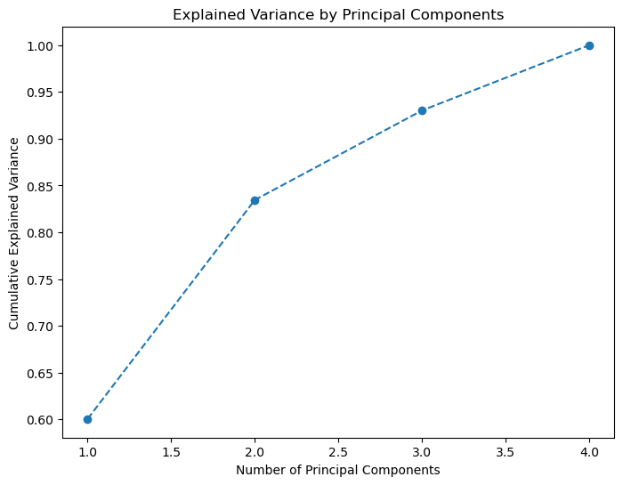

```python
from sklearn.decomposition import PCA

def perform_pca(returns):
    """
    Perform PCA on asset returns.
    :param returns: DataFrame of daily returns.
    """
    pca = PCA()
    pca.fit(returns)
    explained_variance = np.cumsum(pca.explained_variance_ratio_)

    plt.figure(figsize=(8, 6))
    plt.plot(range(1, len(explained_variance) + 1), explained_variance, marker='o', linestyle='--')
    plt.title("Explained Variance by Principal Components")
    plt.xlabel("Number of Principal Components")
    plt.ylabel("Cumulative Explained Variance")
    plt.show()

    return pca

pca = perform_pca(returns)
```

### Monte Carlo simulation - Useful for understanding potential portfolio outcomes

Purpose: Monte Carlo simulation estimates potential future portfolio outcomes by randomly generating return paths based on historical data or assumed distributions.

Process:

- Simulates a large number of portfolio performance scenarios using random sampling.
- Analyzes the distribution of returns to estimate metrics like the probability of loss or the range of returns.

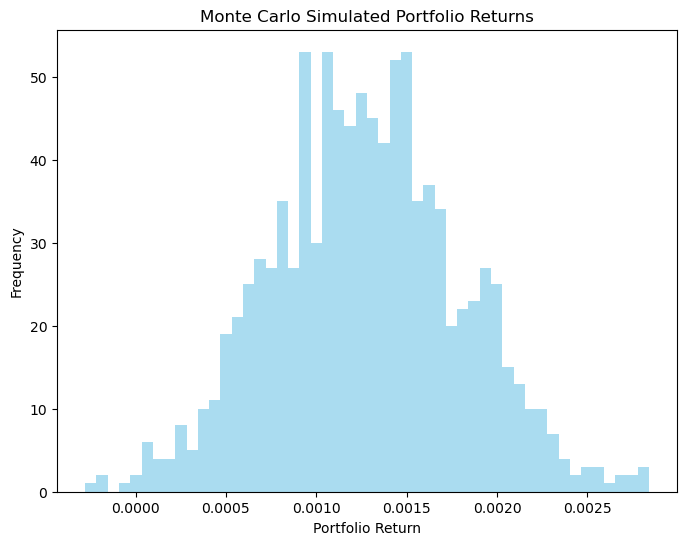

```python
def monte_carlo_simulation(returns, weights, num_simulations=1000):
    """
    Perform Monte Carlo simulation.
    :param returns: DataFrame of daily returns.
    :param weights: Portfolio weights.
    :param num_simulations: Number of simulations.
    """
    mean_returns = returns.mean()
    cov_matrix = returns.cov()
    portfolio_returns = []

    for _ in range(num_simulations):
        simulated_returns = np.random.multivariate_normal(mean_returns, cov_matrix, len(returns))
        portfolio_return = np.dot(simulated_returns, weights).mean()
        portfolio_returns.append(portfolio_return)

    plt.figure(figsize=(8, 6))
    plt.hist(portfolio_returns, bins=50, color="skyblue", alpha=0.7)
    plt.title("Monte Carlo Simulated Portfolio Returns")
    plt.xlabel("Portfolio Return")
    plt.ylabel("Frequency")
    plt.show()

monte_carlo_simulation(returns, optimal_weights)
```